# Case Study 2 - Attrition

Alexandre Jasserme

4/16/2021

# Introdution

The purpose of this project is to analyze a data set of employees data for Frito Lay in order to find the factors that can help predict voluntary employee turnover. Also, a model will be constructed to be able to predict the attrition risk of an employee based on the other variables contained in the data set.

# Preliminary Exploratory Data Analysis - Which data is relevant?

```r
# Loading the libraries
library(ggplot2)
library(GGally)
library(tidyverse)
library(e1071)
library(caret)
# Loading the data
df_all = read.csv("DataFiles/CaseStudy2-data.csv", header = TRUE)
df_no_salary = read.csv("DataFiles/CaseStudy2CompSet No Salary.csv", header = TRUE) # Note that the file "CaseStudy2CompSet No Salary.xlsx" in GitHub was re-saved in CSV format under "CaseStudy2CompSet No Salary.csv"
df_no_attrition = read.csv("DataFiles/CaseStudy2CompSet No Attrition.csv", header = TRUE)

# Starting with a high level exploration of the data
head (df_all)
```

```
##   ID Age Attrition    BusinessTravel DailyRate             Department
## 1  1  32        No     Travel_Rarely       117                  Sales
## 2  2  40        No     Travel_Rarely      1308 Research & Development
## 3  3  35        No Travel_Frequently       200 Research & Development
## 4  4  32        No     Travel_Rarely       801                  Sales
## 5  5  24        No Travel_Frequently       567 Research & Development
## 6  6  27        No Travel_Frequently       294 Research & Development
##   DistanceFromHome Education   EducationField EmployeeCount EmployeeNumber
## 1               13         4    Life Sciences             1            859
## 2               14         3          Medical             1           1128
## 3               18         2    Life Sciences             1           1412
## 4                1         4        Marketing             1           2016
## 5                2         1 Technical Degree             1           1646
## 6               10         2    Life Sciences             1            733
##   EnvironmentSatisfaction Gender HourlyRate JobInvolvement JobLevel
```

[output cut: 41 more lines]

```r
summary(df_all)
```

```
##        ID             Age         Attrition         BusinessTravel
##  Min.   :  1.0   Min.   :18.00   Length:870         Length:870
##  1st Qu.:218.2   1st Qu.:30.00   Class :character   Class :character
##  Median :435.5   Median :35.00   Mode  :character   Mode  :character
##  Mean   :435.5   Mean   :36.83
##  3rd Qu.:652.8   3rd Qu.:43.00
##  Max.   :870.0   Max.   :60.00
##    DailyRate       Department        DistanceFromHome   Education
##  Min.   : 103.0   Length:870         Min.   : 1.000   Min.   :1.000
##  1st Qu.: 472.5   Class :character   1st Qu.: 2.000   1st Qu.:2.000
##  Median : 817.5   Mode  :character   Median : 7.000   Median :3.000
##  Mean   : 815.2                      Mean   : 9.339   Mean   :2.901
##  3rd Qu.:1165.8                      3rd Qu.:14.000   3rd Qu.:4.000
##  Max.   :1499.0                      Max.   :29.000   Max.   :5.000
##  EducationField     EmployeeCount EmployeeNumber   EnvironmentSatisfaction
##  Length:870         Min.   :1     Min.   :   1.0   Min.   :1.000
##  Class :character   1st Qu.:1     1st Qu.: 477.2   1st Qu.:2.000
##  Mode  :character   Median :1     Median :1039.0   Median :3.000
##                     Mean   :1     Mean   :1029.8   Mean   :2.701
##                     3rd Qu.:1     3rd Qu.:1561.5   3rd Qu.:4.000
##                     Max.   :1     Max.   :2064.0   Max.   :4.000
##     Gender            HourlyRate     JobInvolvement     JobLevel
##  Length:870         Min.   : 30.00   Min.   :1.000   Min.   :1.000
##  Class :character   1st Qu.: 48.00   1st Qu.:2.000   1st Qu.:1.000
##  Mode  :character   Median : 66.00   Median :3.000   Median :2.000
##                     Mean   : 65.61   Mean   :2.723   Mean   :2.039
##                     3rd Qu.: 83.00   3rd Qu.:3.000   3rd Qu.:3.000
##                     Max.   :100.00   Max.   :4.000   Max.   :5.000
##    JobRole          JobSatisfaction MaritalStatus      MonthlyIncome
##  Length:870         Min.   :1.000   Length:870         Min.   : 1081
##  Class :character   1st Qu.:2.000   Class :character   1st Qu.: 2840
##  Mode  :character   Median :3.000   Mode  :character   Median : 4946
##                     Mean   :2.709                      Mean   : 6390
##                     3rd Qu.:4.000                      3rd Qu.: 8182
##                     Max.   :4.000                      Max.   :19999
##   MonthlyRate    NumCompaniesWorked    Over18            OverTime
##  Min.   : 2094   Min.   :0.000      Length:870         Length:870
##  1st Qu.: 8092   1st Qu.:1.000      Class :character   Class :character
##  Median :14074   Median :2.000      Mode  :character   Mode  :character
##  Mean   :14326   Mean   :2.728
```

[output cut: 15 more lines]

```
##  Max.   :3.0000   Max.   :40.00     Max.   :6.000         Max.   :4.000
##  YearsAtCompany   YearsInCurrentRole YearsSinceLastPromotion
##  Min.   : 0.000   Min.   : 0.000     Min.   : 0.000
##  1st Qu.: 3.000   1st Qu.: 2.000     1st Qu.: 0.000
##  Median : 5.000   Median : 3.000     Median : 1.000
##  Mean   : 6.962   Mean   : 4.205     Mean   : 2.169
##  3rd Qu.:10.000   3rd Qu.: 7.000     3rd Qu.: 3.000
##  Max.   :40.000   Max.   :18.000     Max.   :15.000
##  YearsWithCurrManager
##  Min.   : 0.00
##  1st Qu.: 2.00
##  Median : 3.00
##  Mean   : 4.14
##  3rd Qu.: 7.00
##  Max.   :17.00
```

We first notice the following: - EmployeeCount: it always has a value of 1 so we will not take it into account for our analysis since it will not be a differentiator to predict attrition or the salary - StandardHours: similar to EmployeeCount, it always has the same value (80) so we will not take it into account - EmployeeNumber: we do not have information how the employee numbers are allocated (if it’s by date of hire or if some employees number could be re-used) so it doesn’t seem useful as a predictor of attrition or salary and we will also not take it into account

Now, we will look at the values in the Over18 column

```r
unique(df_all$Over18)
```

```
## [1] "Y"
```

Since the Over18 column only has 1 value, we will not take it into account for our analysis since it will not be a differentiator to predict attrition or the salary

We will now investigate the 4 variables related to the employees income / rate: MonthlyIncome, HourlyRate, DailyRate and MonthlyRate.

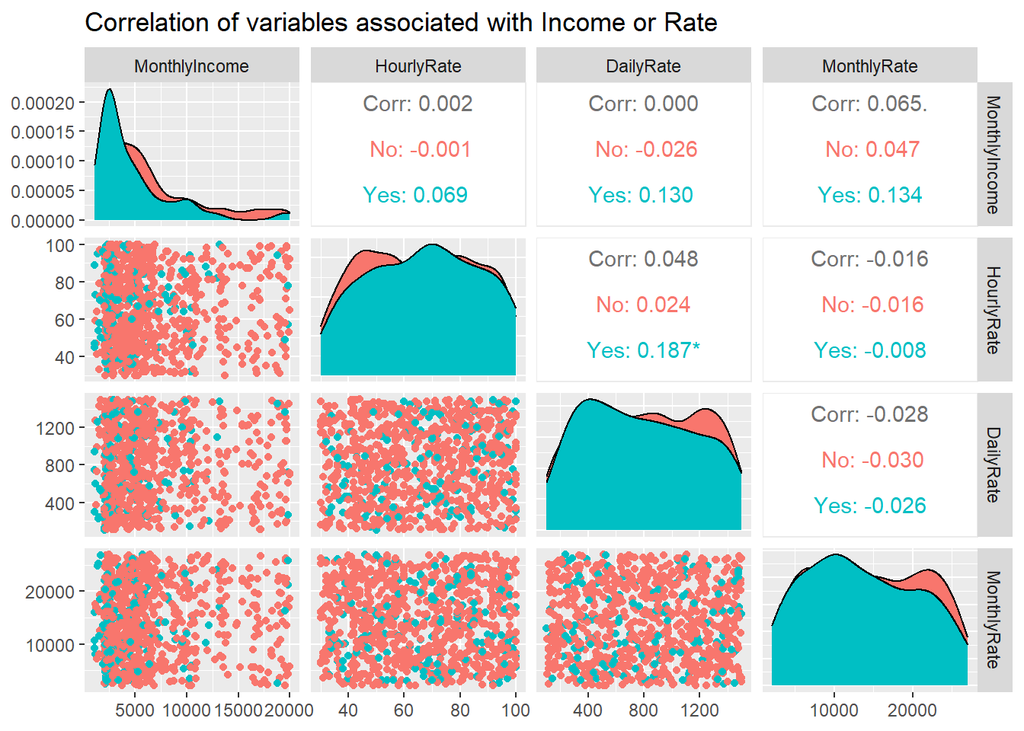

```r
ggpairs(data = df_all, mapping = aes(color = Attrition), columns = c("MonthlyIncome", "HourlyRate", "DailyRate", "MonthlyRate"), title = "Correlation of variables associated with Income or Rate")
```

There is surprisingly very weak correlation between these 4 variables. So we will assume that the most important variable from an employee point of view is the monthly income since it represents actual cash that the employee is receiving. The rates by themselves do not indicate how much the employee is receiving because it depends on the workload. So we will only consider MonthlyIncome for the rest of the analysis and not consider HourlyRate, DailyRate and MonthlyRate. We also notice from the graph at the top left that there is high attrition for lower incomes.

We will now create a simplified data frame by removing the columns that we will not use for the analysis:

```r
df_simplified = df_all %>% select(-EmployeeCount, -StandardHours, -EmployeeNumber, -Over18, -HourlyRate, -DailyRate, -MonthlyRate)
head(df_simplified)
```

```
##   ID Age Attrition    BusinessTravel             Department DistanceFromHome
## 1  1  32        No     Travel_Rarely                  Sales               13
## 2  2  40        No     Travel_Rarely Research & Development               14
## 3  3  35        No Travel_Frequently Research & Development               18
## 4  4  32        No     Travel_Rarely                  Sales                1
## 5  5  24        No Travel_Frequently Research & Development                2
## 6  6  27        No Travel_Frequently Research & Development               10
##   Education   EducationField EnvironmentSatisfaction Gender JobInvolvement
## 1         4    Life Sciences                       2   Male              3
## 2         3          Medical                       3   Male              2
## 3         2    Life Sciences                       3   Male              3
## 4         4        Marketing                       3 Female              3
## 5         1 Technical Degree                       1 Female              3
## 6         2    Life Sciences                       4   Male              3
##   JobLevel                JobRole JobSatisfaction MaritalStatus MonthlyIncome
```

[output cut: 34 more lines]

# More Detailed Exploratory Data Analysis - Which factors influcence attrition?

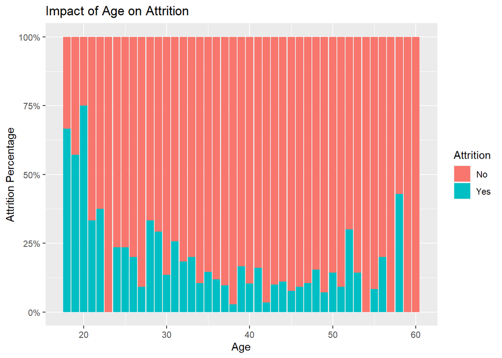

```r
# Creating a function to plot the histograms to analyze the most likely reasons of attrition
attrition_histogram <- function (x_variable) {
  # Extracting the variable name that we will use for the plot label
  var_name = substring(deparse(substitute(x_variable)), 15)

  # Building the plot
  ggplot(df_simplified, aes_string(x = var_name, fill = "Attrition")) +
    geom_bar(position = "fill") +
    scale_y_continuous(labels = scales::percent) +
    xlab(var_name) +
    ylab("Attrition Percentage") +
    ggtitle(paste("Impact of", var_name, "on Attrition"))
}

# Plotting the histograms using the function defined above
attrition_histogram(df_simplified$Age)
```

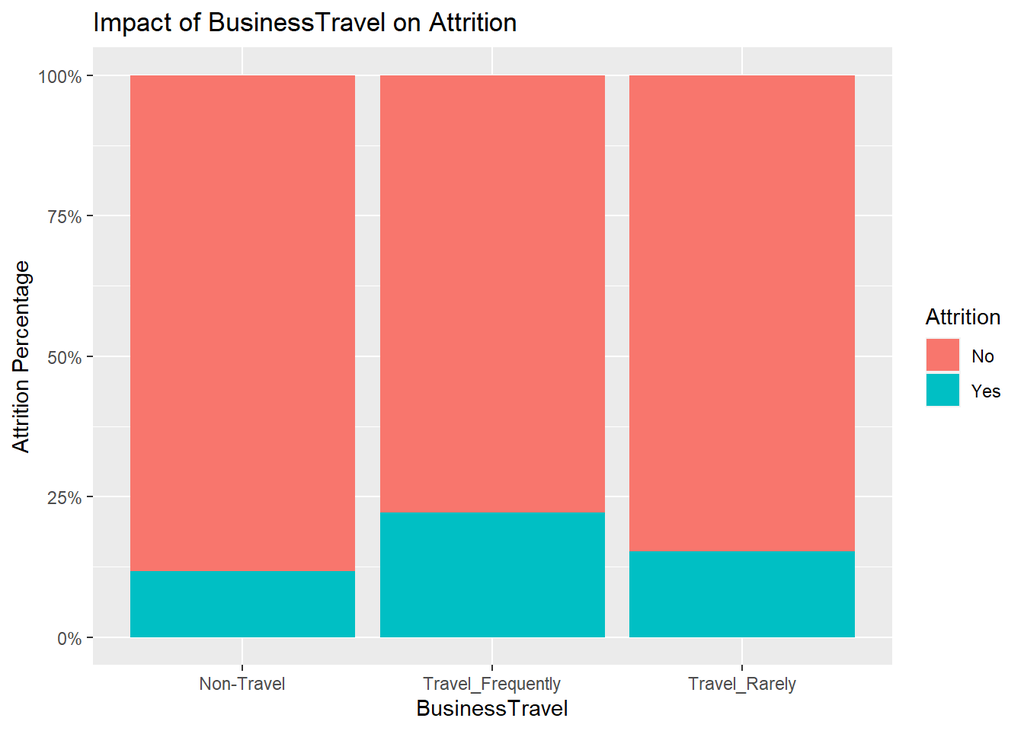

```r
attrition_histogram(df_simplified$BusinessTravel)
```

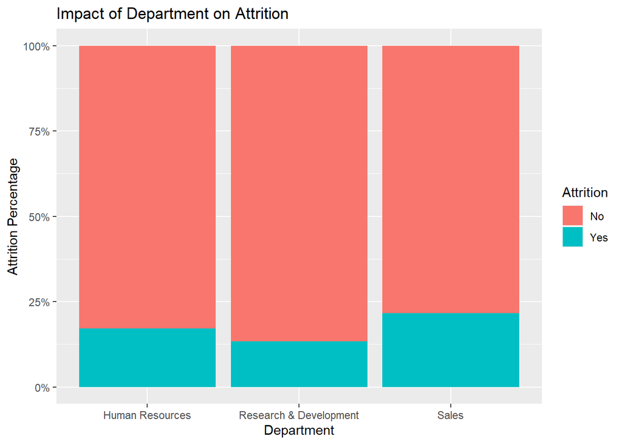

```r
attrition_histogram(df_simplified$Department)
```

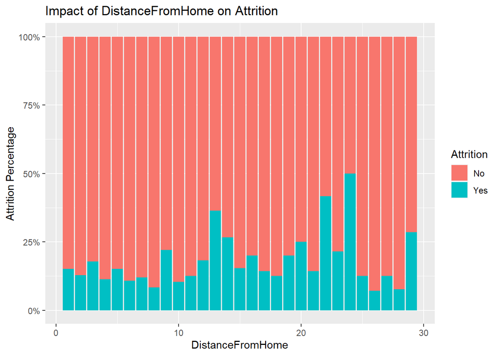

```r
attrition_histogram(df_simplified$DistanceFromHome)
```

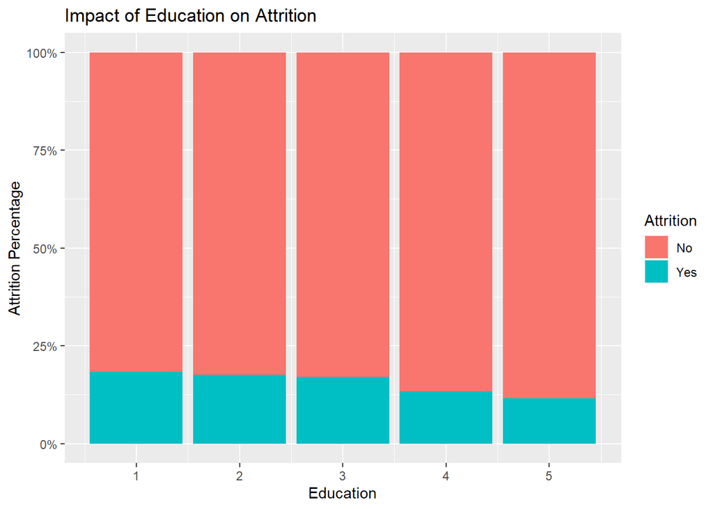

```r
attrition_histogram(df_simplified$Education)
```

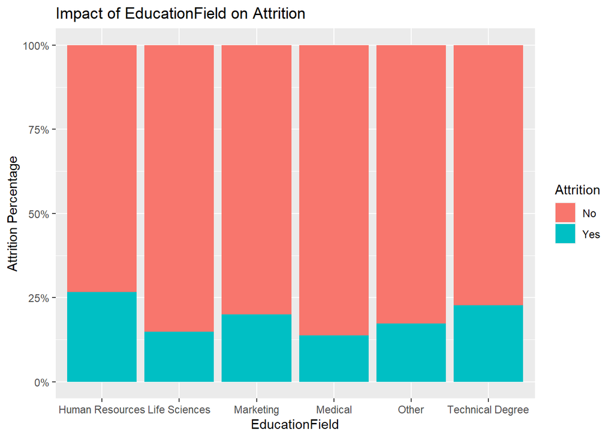

```r
attrition_histogram(df_simplified$EducationField)
```

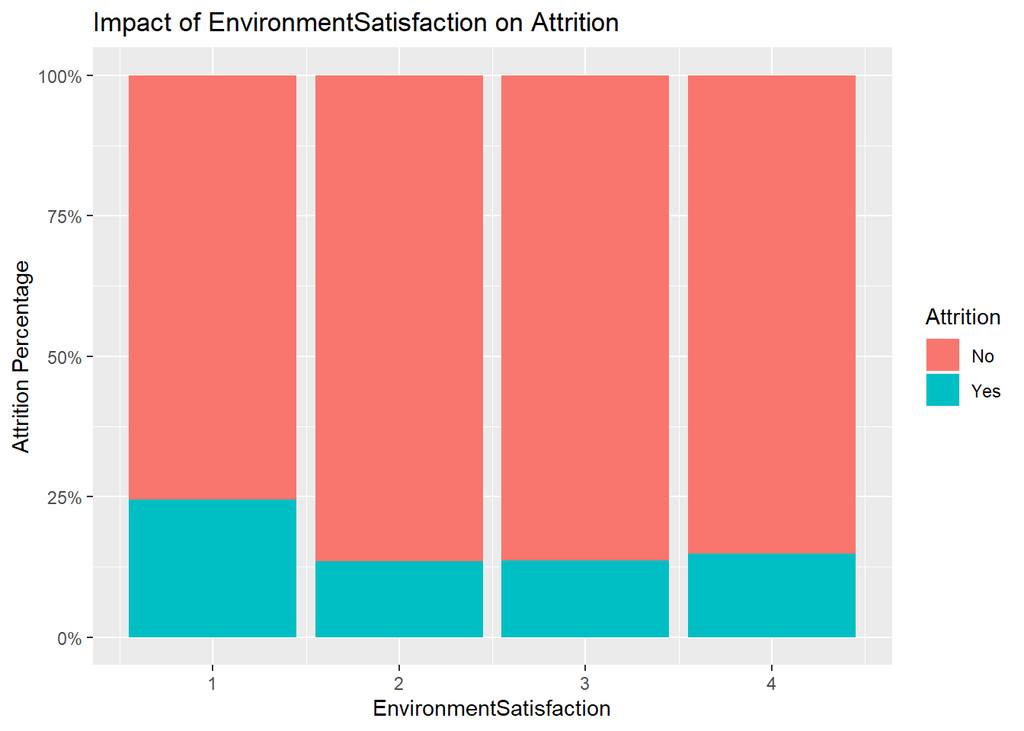

```r
attrition_histogram(df_simplified$EnvironmentSatisfaction)
```

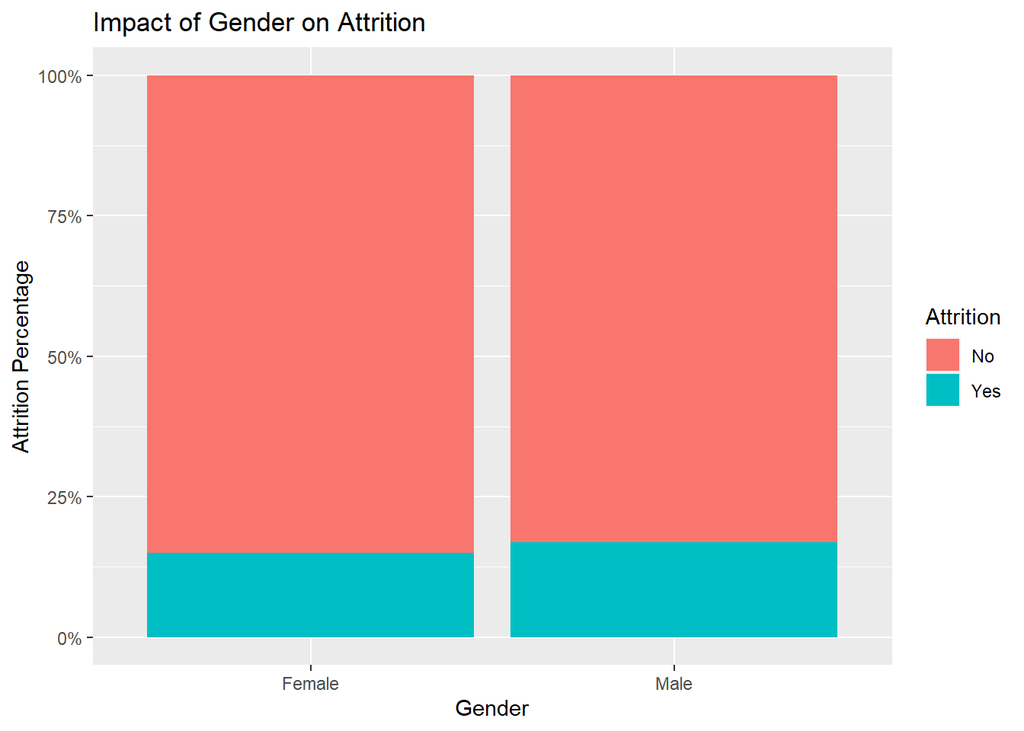

```r
attrition_histogram(df_simplified$Gender)
```

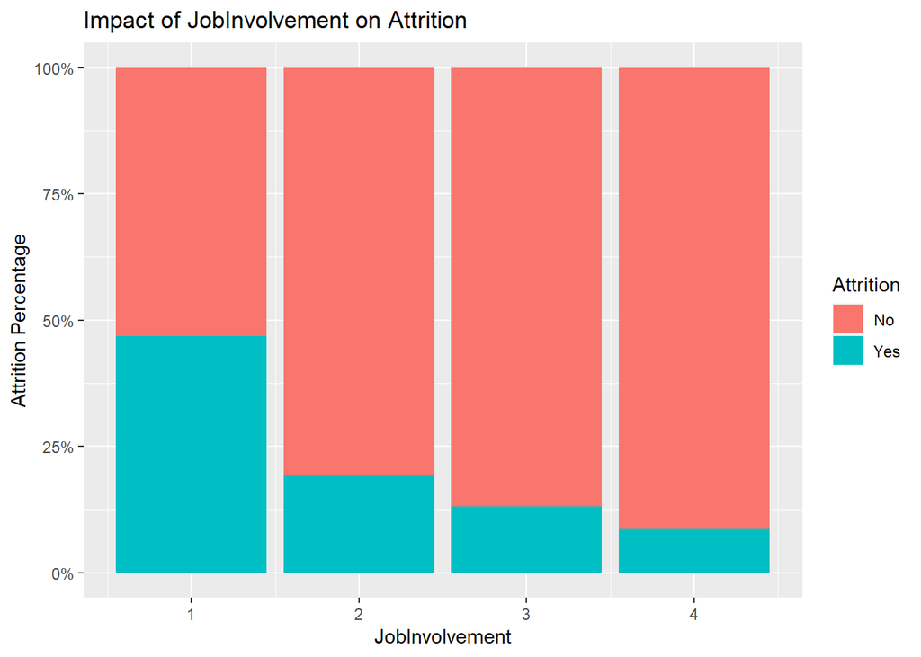

```r
attrition_histogram(df_simplified$JobInvolvement)
```

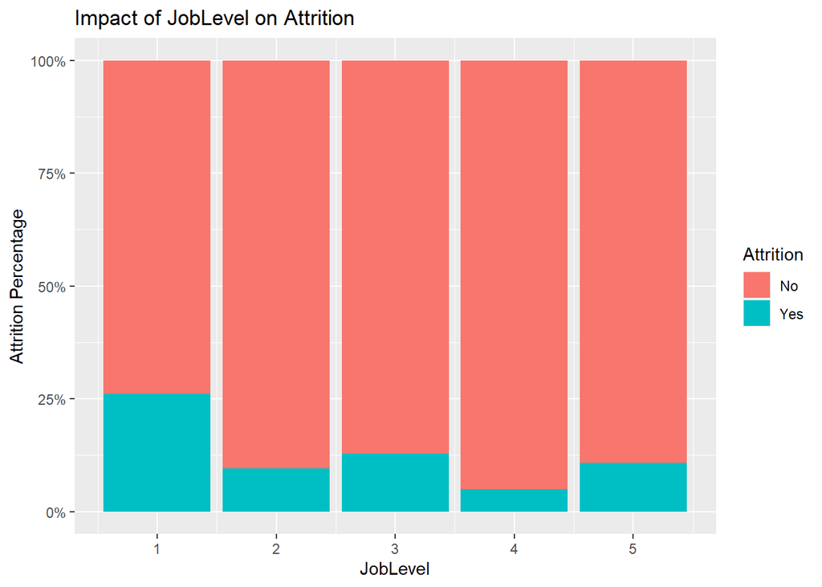

```r
attrition_histogram(df_simplified$JobLevel)
```

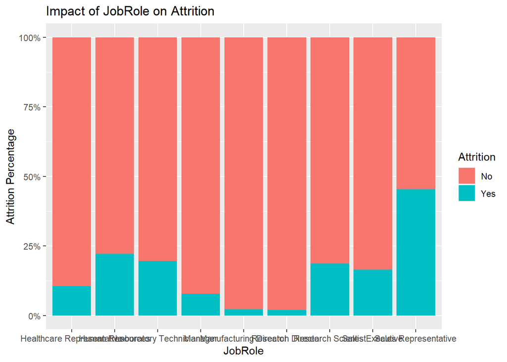

```r
attrition_histogram(df_simplified$JobRole)
```

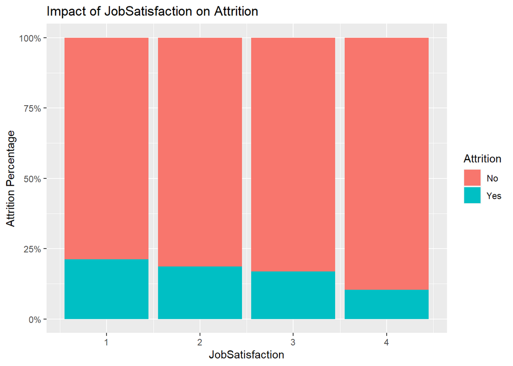

```r
attrition_histogram(df_simplified$JobSatisfaction)
```

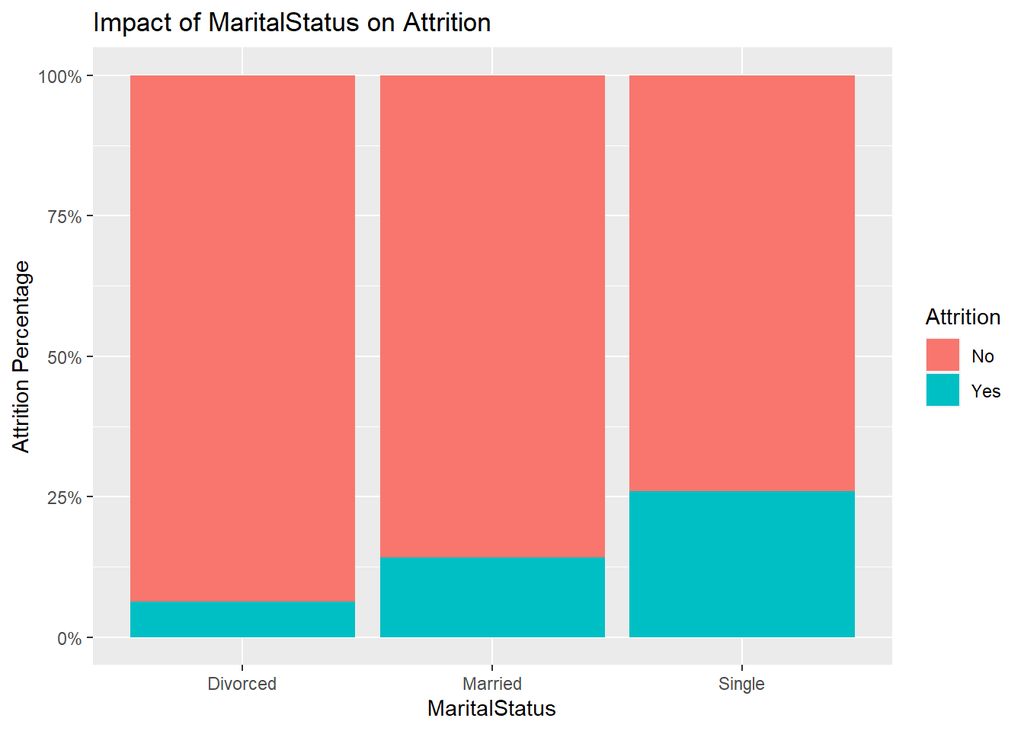

```r
attrition_histogram(df_simplified$MaritalStatus)
```

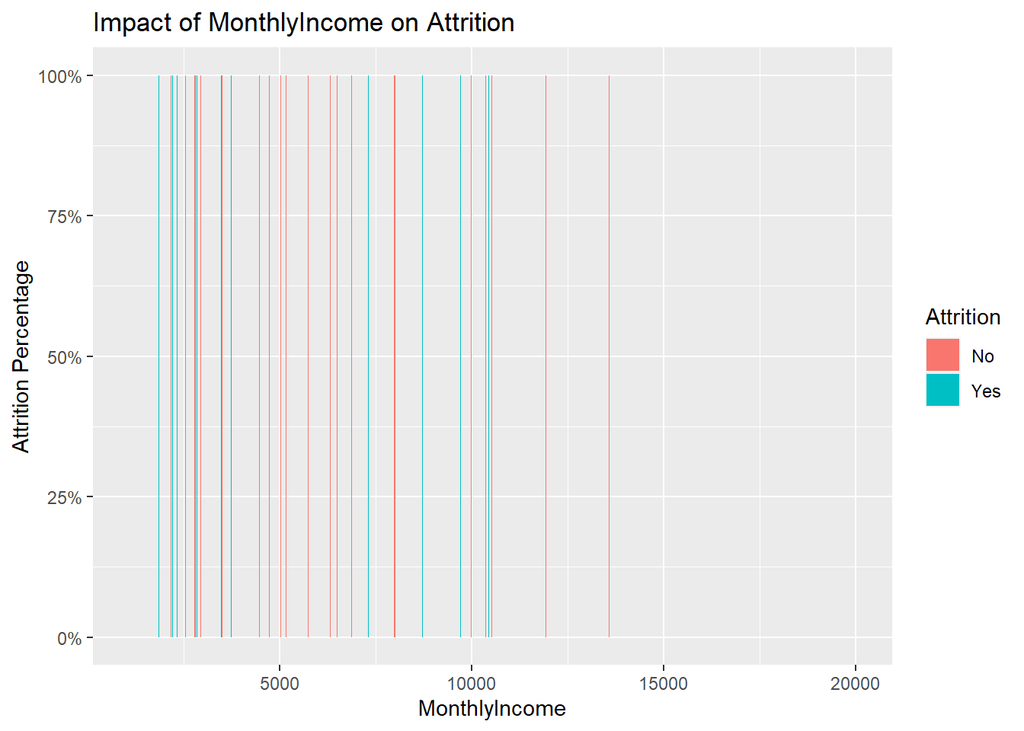

```r
attrition_histogram(df_simplified$MonthlyIncome)
```

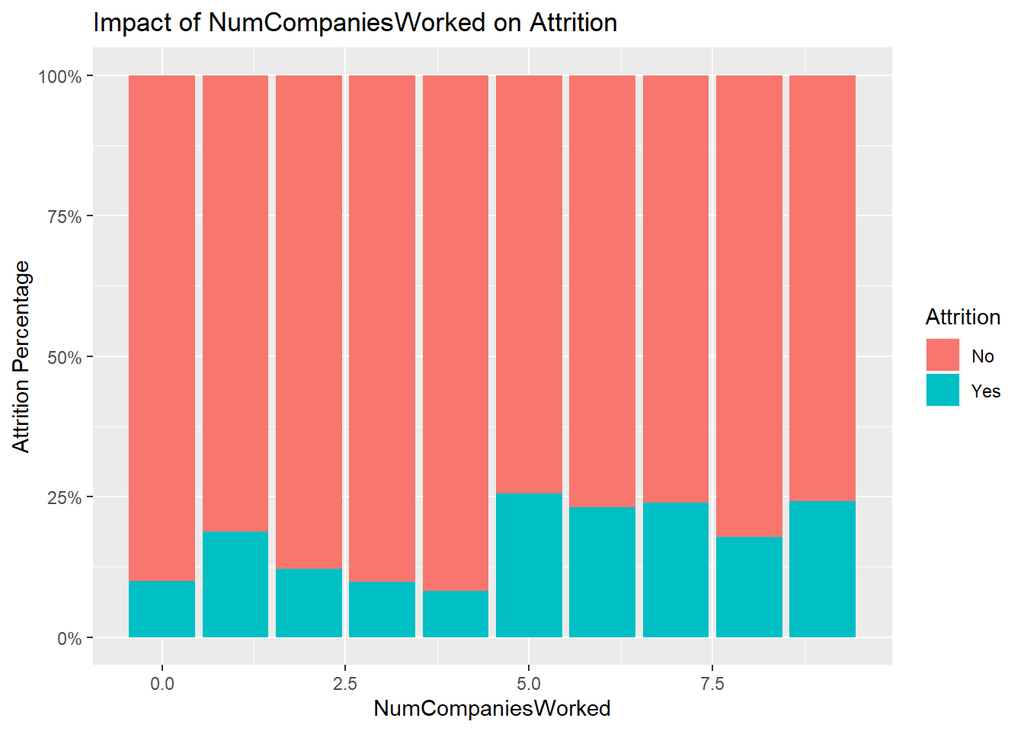

```r
attrition_histogram(df_simplified$NumCompaniesWorked)
```

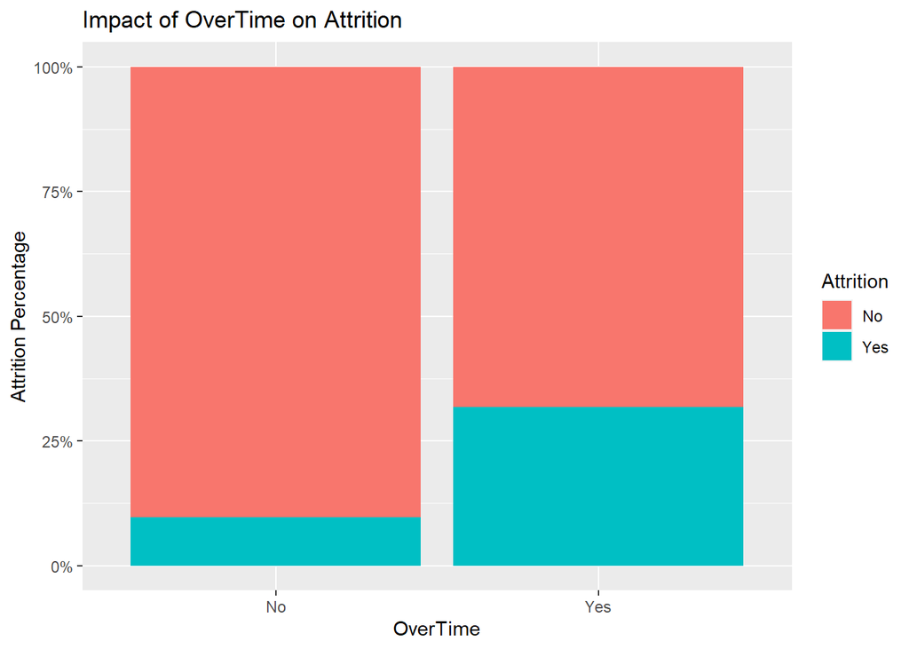

```r
attrition_histogram(df_simplified$OverTime)
```

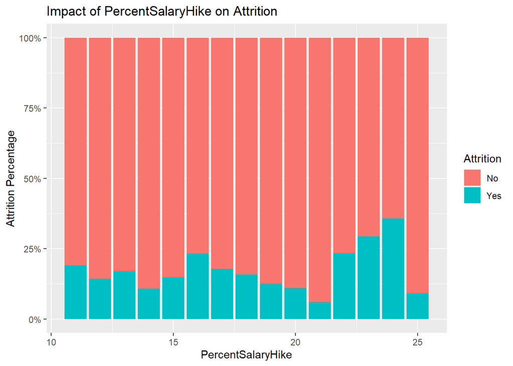

```r
attrition_histogram(df_simplified$PercentSalaryHike)
```

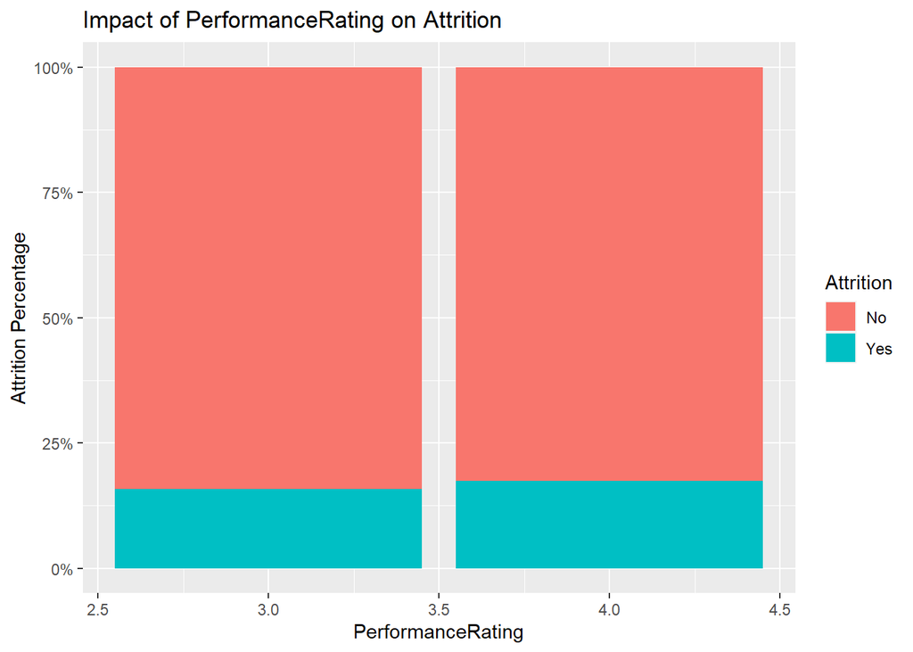

```r
attrition_histogram(df_simplified$PerformanceRating)
```

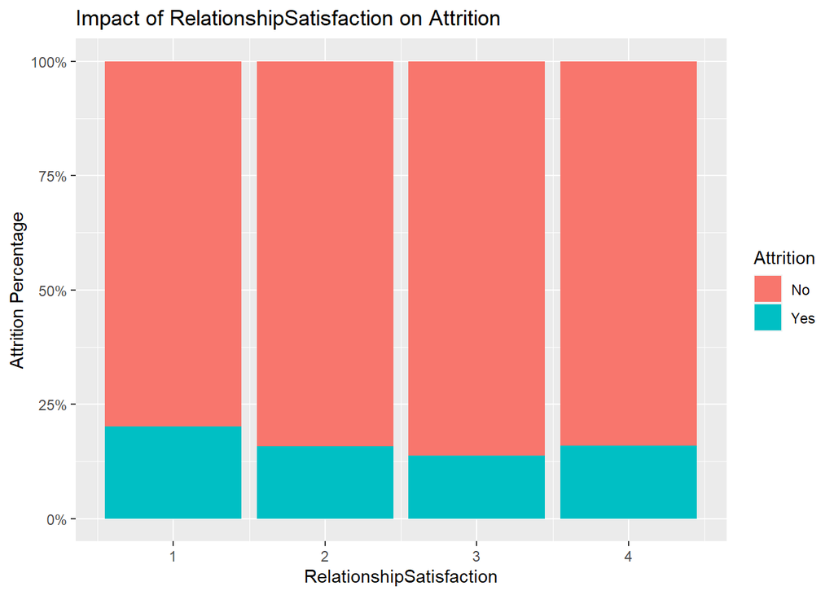

```r
attrition_histogram(df_simplified$RelationshipSatisfaction)
```

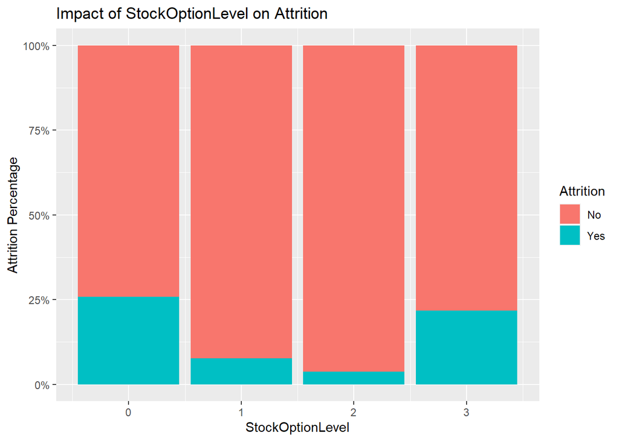

```r
attrition_histogram(df_simplified$StockOptionLevel)
```

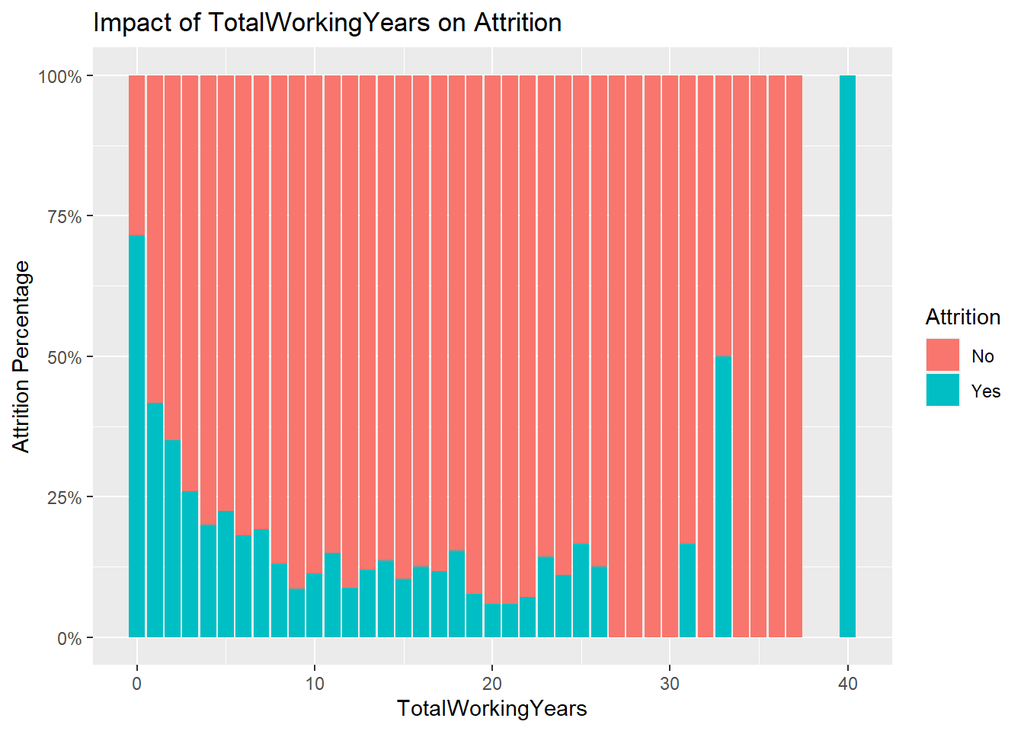

```r
attrition_histogram(df_simplified$TotalWorkingYears)
```

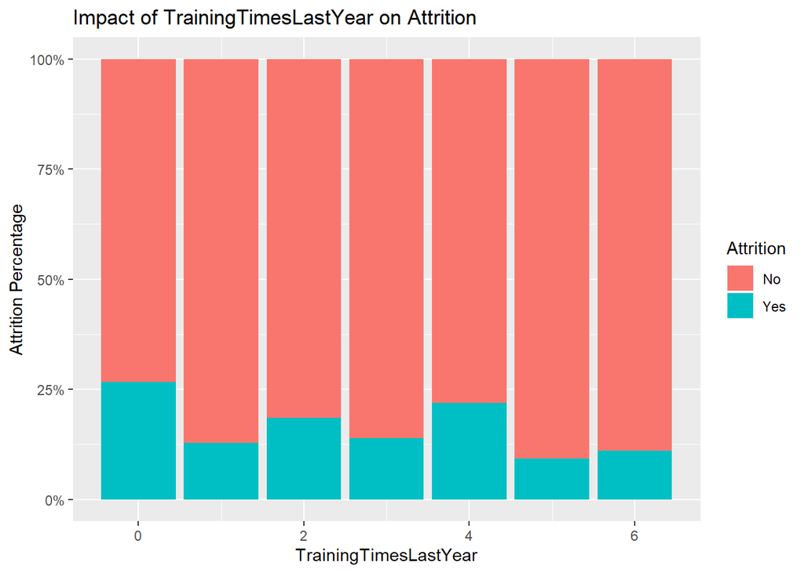

```r
attrition_histogram(df_simplified$TrainingTimesLastYear)
```

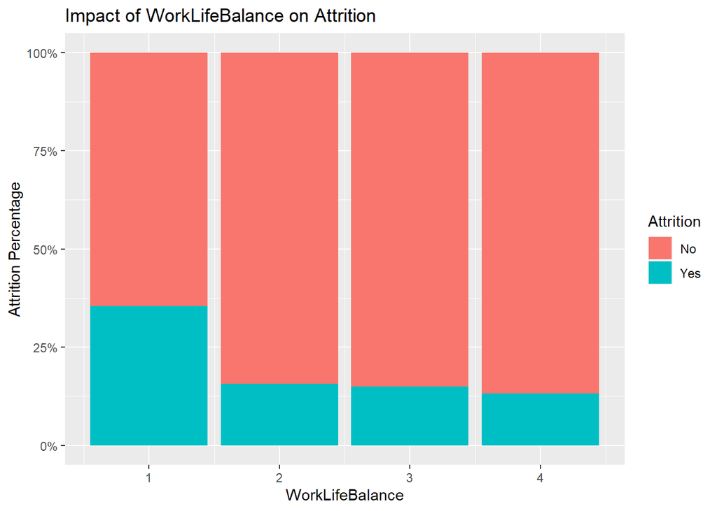

```r
attrition_histogram(df_simplified$WorkLifeBalance)
```

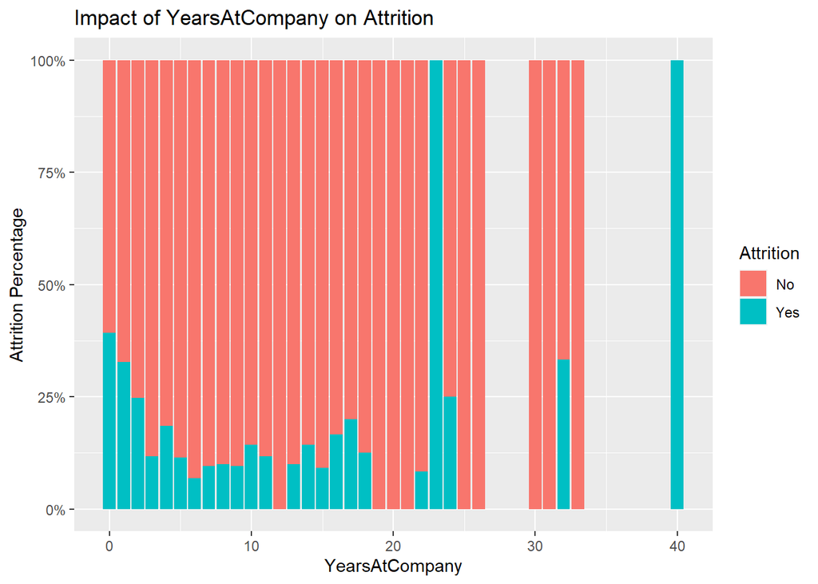

```r
attrition_histogram(df_simplified$YearsAtCompany)
```

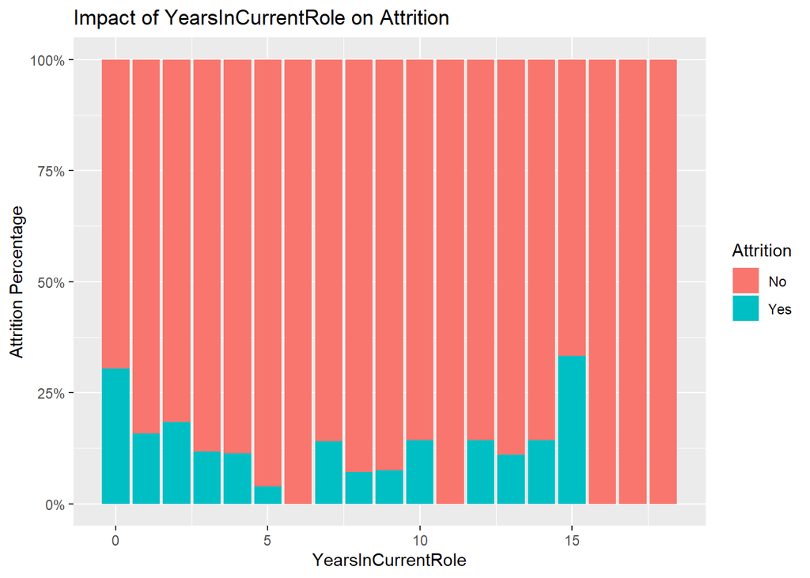

```r
attrition_histogram(df_simplified$YearsInCurrentRole)
```

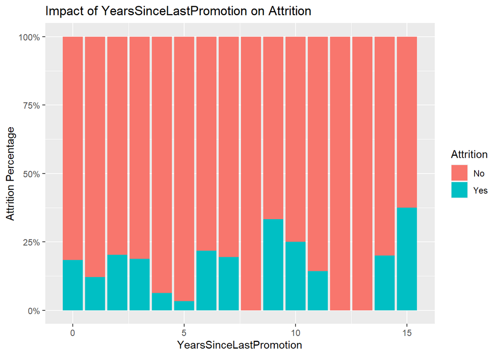

```r
attrition_histogram(df_simplified$YearsSinceLastPromotion)
```

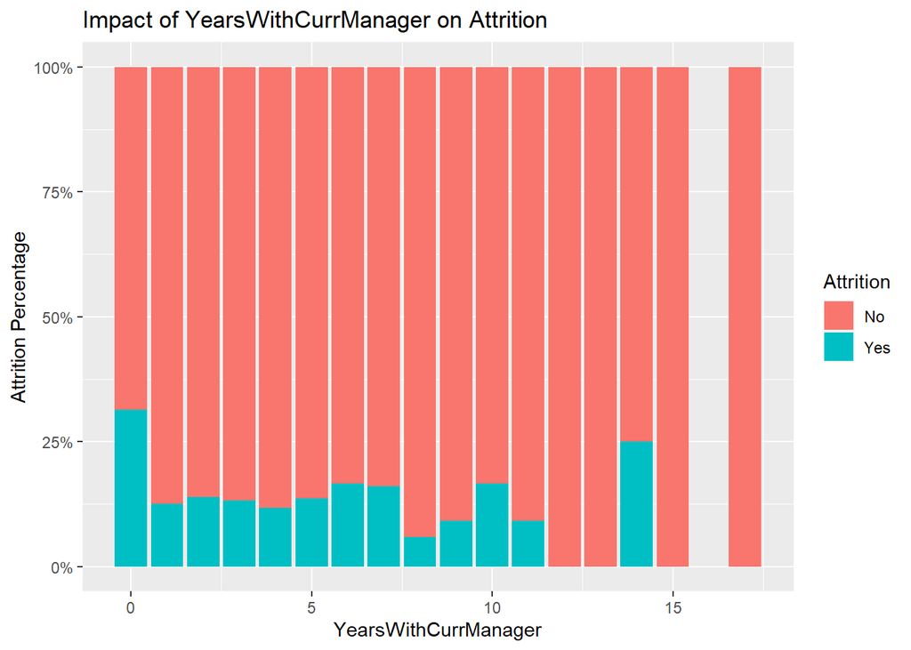

```r
attrition_histogram(df_simplified$YearsWithCurrManager)
```

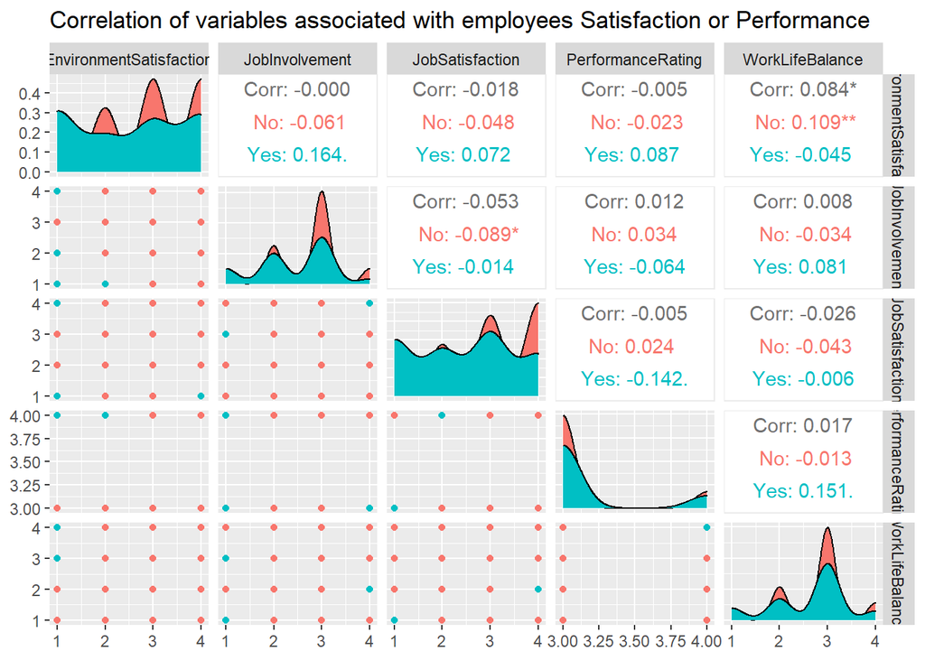

```r
# Exploring some possible correlations:
df_simplified %>% select(EnvironmentSatisfaction, JobInvolvement, JobSatisfaction, PerformanceRating, WorkLifeBalance) %>% ggpairs(aes(color = as.factor(df_simplified$Attrition)), title = "Correlation of variables associated with employees Satisfaction or Performance")
```

# Building a model to predict attrition

```r
# Creating a training set with 70% of the data and a test set with the remaining 30%
set.seed(1234) # For reproducibility of the results
trainIndices = sample(seq(1:length(df_all$ID)),round(.7*length(df_all$ID)))
df_train = df_all[trainIndices,]
df_test = df_all[-trainIndices,]

# The model was initially built using the variables that appeared to have the most significant impact on attrition based on the EDA. It was then refined by trial and error (adding/removing variables one at a time) to find the best balance of sensitivity and specificity and have both over 60%
model = naiveBayes(df_train[,c("Age", "BusinessTravel", "Education", "JobSatisfaction", "MaritalStatus", "MonthlyIncome", "OverTime", "WorkLifeBalance")],factor(df_train$Attrition))

confusionMatrix(table(factor(df_test$Attrition),predict(model,df_test[,c("Age", "BusinessTravel", "Education", "JobSatisfaction", "MaritalStatus", "MonthlyIncome", "OverTime", "WorkLifeBalance")])))
```

```
## Confusion Matrix and Statistics
##
##
##        No Yes
##   No  208   5
##   Yes  39   9
##
##                Accuracy : 0.8314
##                  95% CI : (0.7804, 0.8748)
##     No Information Rate : 0.9464
##     P-Value [Acc > NIR] : 1
##
##                   Kappa : 0.226
##
##  Mcnemar's Test P-Value : 6.527e-07
##
##             Sensitivity : 0.8421
##             Specificity : 0.6429
##          Pos Pred Value : 0.9765
##          Neg Pred Value : 0.1875
##              Prevalence : 0.9464
##          Detection Rate : 0.7969
##    Detection Prevalence : 0.8161
##       Balanced Accuracy : 0.7425
##
##        'Positive' Class : No
##
```

```r
attrition_predictions = predict(model, newdata = df_no_attrition)
data_attrition_predictions = tibble("ID"= df_no_attrition$ID, "Attrition" = attrition_predictions)
write.csv(data_attrition_predictions,"Case2PredictionsAlexandreJassermeAttrition.csv",row.names = FALSE)
```